# Problem Set 6

Exploratory Data Analysis

Your Name

2016-10-19

## Objective

The objective of this assignment is to familiarize your self with the process, specifically the visual process of Exploratory Data Analysis (EDA). I have assigned several readings to support this work and layout an overall procedure. You should read **Zuur et al.** prior to completing this work.

## Directions

Using any data set in `R`, for instance the `titatic` data set found within the `library(datasets)` package as your analysis data. Conduct an EDA on the data set of your choice. Your analysis should follow the “key steps” discussed in **Zuur et al.** and in our lecture discussion.

You analysis should be completed within an **Rmarkdown** document. The assignment should show data import, and any data cleanup that you conduct. The document should show the steps in your EDA including:

- $\geq$ 5 statistical graphics.
- Each graphic should include plot titles, proper axis labels, and legend information, if neccesary.
- Along with each plot include a short statement indicating what you learned from that plot. (This could be anything from verifying a `sort()` or `filter()` call to a `mosaic()` plot showing sample size variability).

The final document should be converted using the `knitr` package to an `.html` file and submitted via Moodle for evaluation. Remember to properly name your file as: `YourName_ANLY512-50_Fall.html`.

### Calling all the helpers

```r
library(tidyverse)
library(readr)
library(readxl)
library(knitr)
library(magrittr)
library(datasets)
```

For this analysis, I am going to explore the diamonds dataset with the ggplot 2 packages, which could be summarised by `glimpse()`

```r
glimpse(diamonds)
```

```
## Observations: 53,940
## Variables: 10
## $ carat   <dbl> 0.23, 0.21, 0.23, 0.29, 0.31, 0.24, 0.24, 0.26, 0.22, ...
## $ cut     <ord> Ideal, Premium, Good, Premium, Good, Very Good, Very G...
## $ color   <ord> E, E, E, I, J, J, I, H, E, H, J, J, F, J, E, E, I, J, ...
## $ clarity <ord> SI2, SI1, VS1, VS2, SI2, VVS2, VVS1, SI1, VS2, VS1, SI...
## $ depth   <dbl> 61.5, 59.8, 56.9, 62.4, 63.3, 62.8, 62.3, 61.9, 65.1, ...
## $ table   <dbl> 55, 61, 65, 58, 58, 57, 57, 55, 61, 61, 55, 56, 61, 54...
## $ price   <int> 326, 326, 327, 334, 335, 336, 336, 337, 337, 338, 339,...
## $ x       <dbl> 3.95, 3.89, 4.05, 4.20, 4.34, 3.94, 3.95, 4.07, 3.87, ...
## $ y       <dbl> 3.98, 3.84, 4.07, 4.23, 4.35, 3.96, 3.98, 4.11, 3.78, ...
## $ z       <dbl> 2.43, 2.31, 2.31, 2.63, 2.75, 2.48, 2.47, 2.53, 2.49, ...
```

### Plot 1: Dimond Carat Distribution

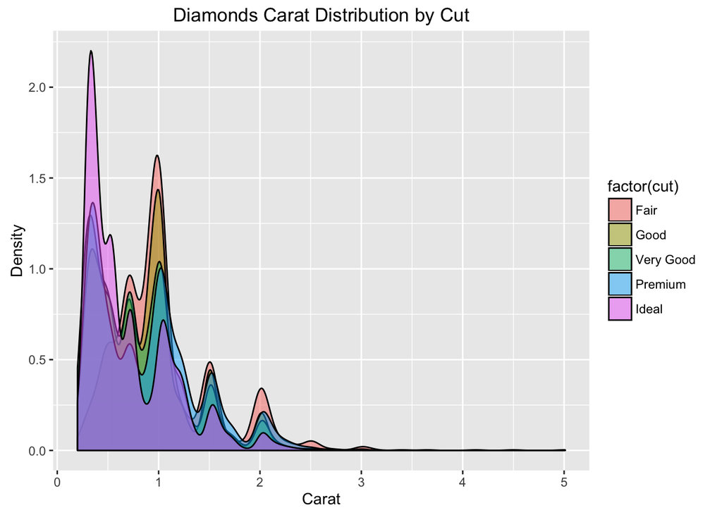

```r
diamonds %>%
    ggplot(aes(carat, fill = factor(cut))) +
    geom_density(alpha = 0.5) +
    ggtitle("Diamonds Carat Distribution by Cut") +
    labs(x="Carat",y="Density")
```

> There are clearly clusters in the carat distribution and most diamonds are under 3 carats

### Plot 2: Relationship between Diamonds Carat and Price

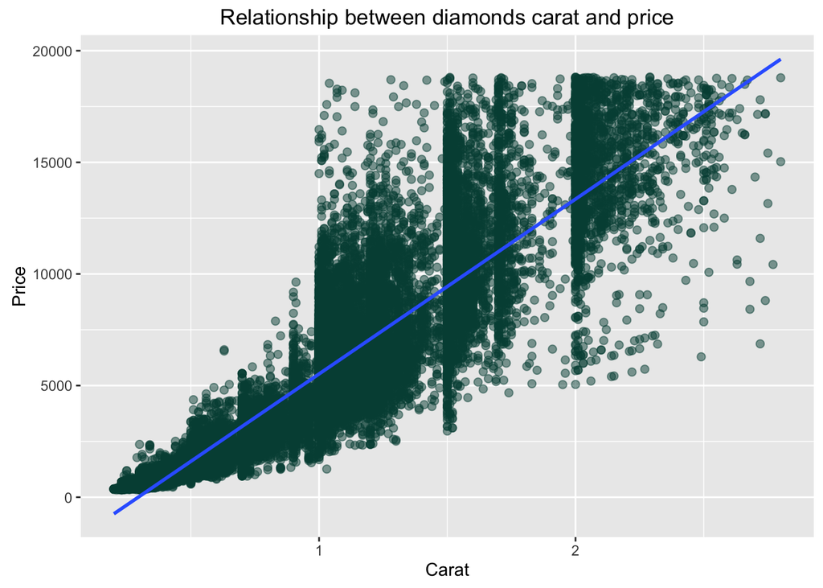

```r
diamonds %>%
    filter(carat < 3) %>%
    ggplot(aes(x=carat, y=price)) +
    geom_point(alpha = 0.5, size = 2, color = "#004D43") +
    stat_smooth(method="lm") +
    ggtitle("Relationship between diamonds carat and price") +
    labs(x="Carat",y="Price")
```

> There is a significant positive relationship btw diamonds carat and its price.

### Plot 3: Relationship between diamonds price and cut.

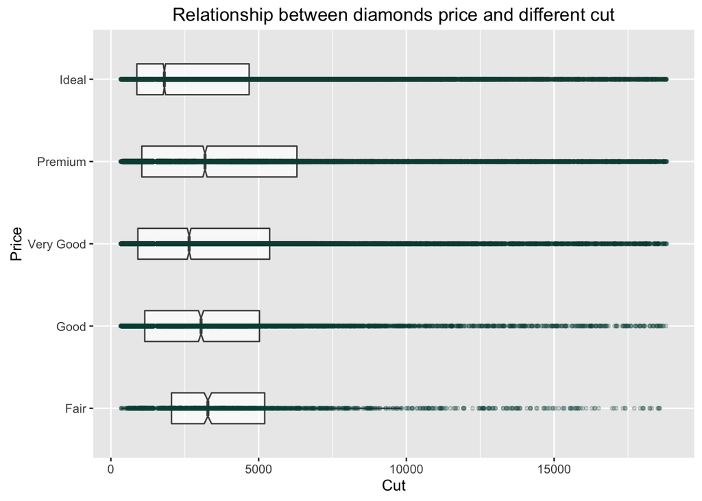

```r
diamonds %>%
    ggplot(aes(cut, price)) +
    geom_boxplot(outlier.shape = NA, width  = 0.5, alpha = 0.7, color="#4C4C4C", notch = T) +
    coord_flip() +
    geom_point(color = "#004D43", alpha = 0.2, size = 1) +
    ggtitle("Relationship between diamonds price and different cut") +
    labs(x="Price",y="Cut")
```

### Plot 4: Relationship between cut and color

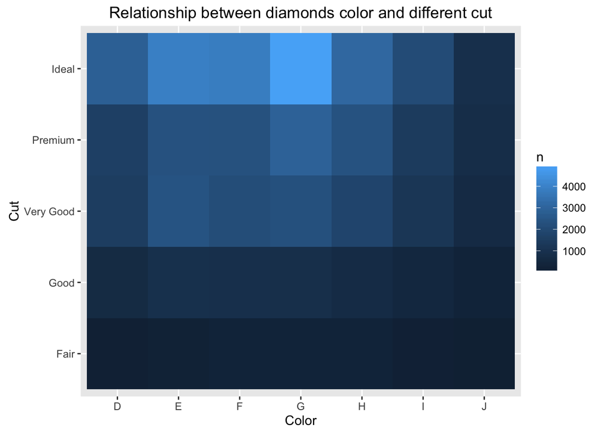

```r
diamonds %>%
  count(color, cut) %>%
  ggplot(mapping = aes(x = color, y = cut)) +
    geom_tile(mapping = aes(fill = n)) +
    ggtitle("Relationship between diamonds color and different cut") +
    labs(x="Color",y="Cut")
```

> ideal cut and color G is most common

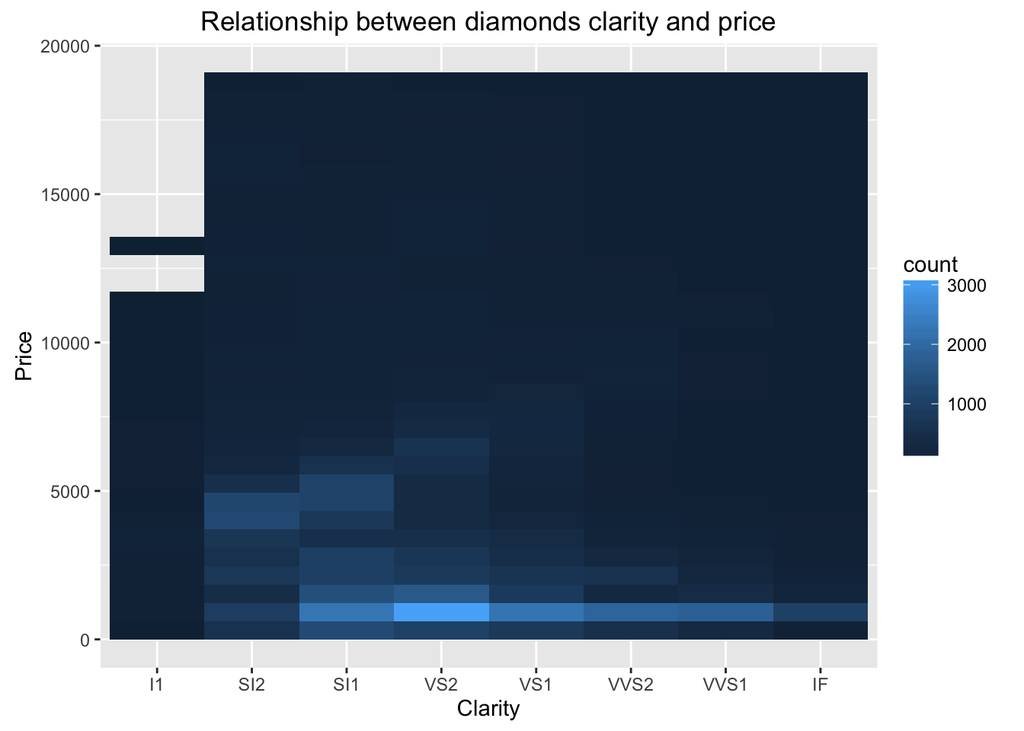

```r
diamonds %>%
    filter(carat < 3) %>%
    ggplot(aes(x=factor(clarity), y=price)) +
    geom_bin2d() +
    ggtitle("Relationship between diamonds clarity and price") +
    labs(x="Clarity",y="Price")
```

> Most common clarity combination is under $2000 with VS2 clarity